# Methods of correction for biased sampling in species distribution modeling

Robert Richards, Paige Miller, Gio Righi

May 3, 2016

## Introduction

Ecologists, managers, and public health oﬃcials use species distribution models (SDMs) to predict the likelihood of species presence across a landscape of importance (e.g. , , ). Construction of these models requires ‘training’ data representing known locations where the species of interest is present and absent (see for a review). Presence-absence data produced through systematic samples chosen unbiasedly from the landscape of interest are the gold standard in this training data. Unfortunately examples of such data sets are few and far between. Much more common are examples of ‘Presence-only’ data, such as records from natural history museums or much citizen science data . Though presence-only records provide less information than systematic presence-absence records (and limit the types of models that can be used) this data format can provide distinct advantages as well.

Notably, these methods are not subject to the measurement uncertainty associated with absence records. If a species is detected at a location then it is deﬁnitively present in that location at that time. If, however, a species is not detected at a given location that species may be genuinely absent, or simply have gone undetected by the researcher despite its presence . Often even true absences may bear the mark of dispersal barriers or preventive biotic interactions leading to areas that are environmentally habitable by the species being marked as absences. Though presence-only data can also bear the imprint of such non-environmental variables (species may be detected in sink habitats as a result of migration from permanently habitable source habitats) (), this burden is generally considered to weigh more heavily on absence data. Presence only data are not, however, without other issues for species distribution modelers.

Generally, presence-only models rely on the assumption that presence data are sampled unbiasedly from the distribution of a species. Violation of this assumption can cause problems with both model ﬁtting and model evaluation (). A number of methods have been proposed for addressing this problem of spatial sampling bias. They tend to fall into two major categories: (1) Thinning, a process in which a subset of presence points is selected for model ﬁtting in such a way as to minimize geographic or environmental aggregation, and (2) accounting for bias within the model. The second method can be accomplished by bias weighting, in which points are assigned weights for model ﬁtting based on the inverse of their association with sampling bias (e.g. , (Stolar:2015je}). Alternatively bias can be corrected within a model by fitting the likelihood of observing a species presence as a function of both environmental variables and ‘observer bias’ variables .

Explicitly correcting or accounting for bias is generally considered the preferable method both because it attempts to reconstitute the unbiased distribution for modeling and because it retains all training records. Unfortunately these methods can be difficult to realize with most data sets as they tend to require a baseline understanding of the way the sampling is biased geographicly. This understanding is often derived from the bias observed in sampling distributions of other species in the same regions (e.g. ) or basic assumptions about the way that researchers tend to sample (e.g. bias in favor of areas close to roads or population centers, , ). In the absence of such understanding data thinning provides a ‘researcher behavior’ free method of improving predictions in the presence of spatial sampling bias.

Thinning addresses spatial bias from a different perspective. Rather than attempting to determine the nature of the sampling bias, thinning removes aggregated points. In this way it reduces the spatial bias at a given scale at the cost of a smaller training sample. Thinning has been implemented and tested in a number of diﬀerent ways. The distinctions between these methods fall along 2 distinct axes: (1) the method (grid based, distance based, or cluster analysis based) used to thin the data points and (2) the axes (geographic or environmental) along which the thinning of points is performed (Table 1). Likely the most common form of thinning performed in modern SDM is the type implemented in MaxEnt (the leading presence-background SDM). MaxEnt selects one presence point per grid-cell of the environmental covariate grid. This process can also be interpreted as MaxEnt assigning a presence or non-presence identity to each grid-cell based on whether a presence point is found inside of it (something else). Grid-based geographic ﬁltering has been used with other SDMs as well . Boria et al. propose and test an alternative method of geographic thinning in which a minimum allowable distance between points is imposed on presence data using an algorithm that maximizes the total number of retained points given this constraint (see Methods for further details).

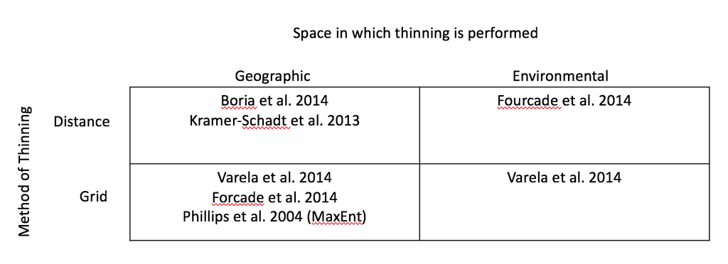

Table 1. Previous reports on data thinning

Recently, eﬀorts have been made to identify which data processing methods, including Thinning (see Table 1), provide the best model performance in the presence of spatially biased data. Some focus on the merits of geographic thining (e.g , ) while others attempt to compare performance across environmental and geographic methods (e.g. , ). Results of such studies have been mixed. Varela et al. compare the relative performance of grid-based environmental and geographic thinning to ﬁnd the clear superiority of environmental methods. They themselves highlight, however, that this relative performance may be context speciﬁc. Their study comprised the Iberian peninsula, a particularly environmentally heterogeneous area. Environmental thinning may perform better in this setting because it retains a larger number of unique points in environmental space while geographic thinning will tend to discard neighboring points that are in fact very diﬀerent environmentally. Alternatively, spatial heterogeneity of environment may result in a spatial sampling bias not manifesting as a clear bias in environmental space. This interpretation would suggest that environmental thinning ought to be less able to correct the bias in the data. Interestingly, Fourcade et al. , in a comparison of a number of diﬀerent methods for limiting the eﬀect of spatial sampling bias on MaxEnt modeling, found ‘Systematic Sampling’, a methodological equivalent of our geographic grid based thinning, to be the generally superior method. This discrepancy between results could be due to diﬀerences in the taxa modeled, the geographic region (North America for Fourcade et al.), or simply the fact that the latter group’s implementation of environmental thinning was a cluster analysis (choosing a single point from identified clusters, rather than grid based thinning. Though more work certainly remains to be done in this area, thinning performance is beginning to appear to be both system and implementation dependent.

Relatively little effort has been made to assess the effect of resolution of thinning on model fit. Most thinning attempts, even those whose stated goal is to measure the effects of thinning, set a single resolution of thinning for all analyses (, , , ). We instead allow the resolution of our thinning methods to vary over a range in an effort to determine the effect of thinning distance on model fit. This process allows us to compare the performance of each individual model to the ‘ideal’ thinning distance (the distance at which spatial autocorrelation is highest) and the model average of all thinning distances. Model averaging has been used to great effect in SDM both in the form of bootstrap aggregation , , and of the combination of predictions of different modeling methods . Therefore it is possible that if our ‘ideal’ thinning distance should prove inconsistent in its performance a model averaging approach will outperform an arbitrarily chosen thinning distance. Model averaging approaches often significantly outperform even the best fit models .

Here we apply the 2 primary data thinning methods, geographic and environmental thinning, at a series of resolutions in an eﬀort to measure the overall performance of each method across 30 simulated species. We then apply the best performing methods from this simulation study to 2 members of the Culex mosquito species complex in Africa whose predicted distributions have serious public health implications for the spread of West Nile Virus and whose presence data seems to be highly aggregated in geographic.

## Methods

### Environmental Data

Environmental covariate rasters were downloaded from the BIOCLIM database (, http://www.worldclim.org/bioclim). Monthly temperature range variables were also constructed . Data were rescaled by subtracting the raster mean and dividing by the raster standard deviation. Variables that are ecdf transformed are not rescaled.

### Culex Data

Presence records for 2 species of Culex mosquitoes (*C. pipiens* and *C. quinquefasciatus*) on the continent of Africa were collected in the Vector Map database (http://vectormap.si.edu/dataportal.htm). Records were initially reduced to unique geographic locations, randomly sampled, biasedly sampled according to distance from the major population centers, and then were subjected to each of the following thinning methods.

### Data Processing

#### Geographic Thinning

Distance-based thinning was performed using an adaptation of the R package spThin . The thinning algorithm accepts a minimum allowable distance (x) between points, calculates the number of occurrence records within this distance for each presence point, and identiﬁes the record(s) with the greatest number of neighbors within x. One of these records is then eliminated at random and the process is repeated until no remaining point has a neighbor within x. Thinning was performed at a series of scales (x=.16 degrees, 1 degree, 5 degres) to assess the eﬀect of thinning distance on model output. Grid-based thinning was performed using the gridSample function in the R package dismo . We provide the function with a raster grid of a speciﬁc resolution (cell size) and (much like the MaxEnt functionality discussed above) one presence point is chosen at random in each grid cell. This type of thinning was performed at the resolution of the environmental variables (.1666 degrees) as well as lower resolutions (1 and 5 degrees). Due to the large spatial extent of Africa the actual distance in meters corresponding to a degree varies substantially latitudinally across the continent.

#### Environmental thinning

We performed a principal components analysis (PCA) of the re-scaled baseline environmental data. Approximately 55% of the variation in environmental covariates was explained by the ﬁrst two principle components . Thus, we sought to test whether ﬁltering points in two-dimensional PCA space, deﬁned by the ﬁrst two principal components, is a viable option for correcting spatially biased data. Again two methods of thinning were tested: (1) distance thinning and (2) grid-based thinning. The implementations of these thinning methods were identical to those used for Geographic thinning.

### Assessing optimal thinning resolution and Model Averaging

In order to further examine the effect of thinning resolution on model fit, we isolated environmental distance thinning as a good thinning method and performed a more thorough test of how a range of thinning distances influences model performance. We attempted, unsuccessfully, to determine an ideal thinning resolution based on linearized Ripley’s K (and L?) analyses. As a result we instead fit models to points that were thinned at distances in PCA space of 0.2-5 increasing at increments of 0.25. Each of the models trained on these data sets was evaluated individually and their predictions were then averaged and the performance of this consensus model was then evaluated.

### Species Distribution Models

LOBAG-OC was the primary modeling method used. Unlike the more widely used MaxEnt LOBAG-OC is a true presence-only method in that the model is trained using exclusively the point presence data, with no requirement for randomly sampled background (or ‘pseudo-absence’) points.

### Model Evaluation

Models were evaluated using the 2000 presence-absence evaluation points drawn from each virtual species’ distribution. Area under the Receiver Operator Curve (AUC) values were calculated and for all filtering methods were converted into delta AUC values: representing the proportion of performance lost to bias that is regained through thinning .

### Culex range predictions

The ultimate goal of this work was to produce accurate maps of the distribution of members of the *Culex* species complex on the continent of Africa. As such we applied the mean model predictions across a range of environmental distance thinning to the geographically aggregated occurrence data mentioned above to produce predicted species distributions for *Culex pipiens* and *Culex quinquifasciatus*.

## Results

### Environmental Thinning vs. Geographic Thinning

ANOVA analysis revealed the delta AUC of our 12 thinning methods (2 thinning spaces x 2 thinning methods x 3 thinning distances) significantly differed by Space (environmental or Geographic, p<.0001) and Distance (p<.0001) . Post hoc Tukey analysis reveals that all significant differences between classes were either (1) environmental thinning methods significantly outperforming geographic thinning methods or (2) methods with a larger distance (lower resolution) outperforming methods performed in the same space with a smaller distance (higher resolution). A substantial amount of heterogeneity in model performance can nonetheless be seen across our 30 simulated species resulting in inconsistency in the best method (Figure). The best fit model for 20 species was based on data thinned in environmental space. Only 2 species had best models fit to data thinned at the highest resolution (shortest distance).

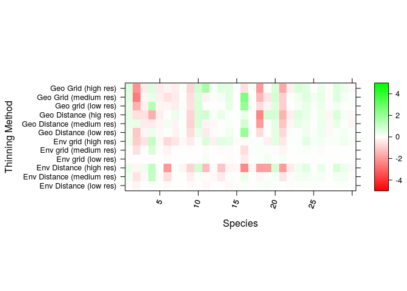

Thinning our data in environmental space at 20 distances from 0.2 to 4.95 revealed no significant pattern in delta AUC across 10 species (p>0.05) (Fig. 2). Instead, there was a large amount of variability across species and across each thinning distance. Some species were easier to predict (e.g. species 3 and 4), while others were harder to predict (e.g. species 5 and 8). The mean delta AUC of the averaged LO-BAG models across the 20 distance thinning precedures was 0.48.

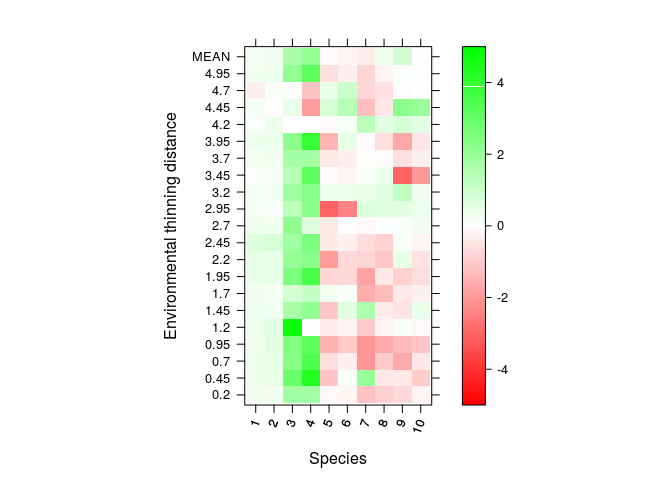

```
##
## Call:
## lm(formula = DAUC ~ distance, data = DAUCmatrix)
##
## Residuals:
##     Min      1Q  Median      3Q     Max
## -3.4344 -0.8029 -0.1898  0.2428  8.4965
##
## Coefficients:
##             Estimate Std. Error t value Pr(>|t|)
## (Intercept)  0.24668    0.22770   1.083    0.280
## distance     0.03962    0.07716   0.513    0.608
##
## Residual standard error: 1.573 on 198 degrees of freedom
## Multiple R-squared:  0.00133,    Adjusted R-squared:  -0.003714
## F-statistic: 0.2636 on 1 and 198 DF,  p-value: 0.6082
```

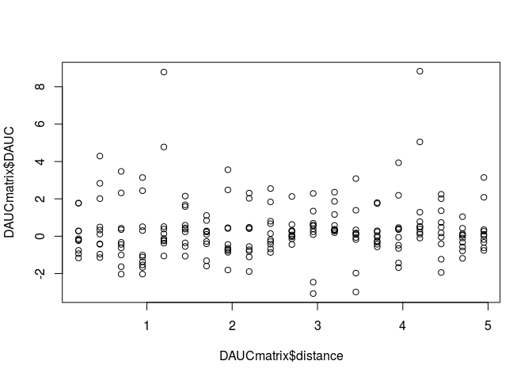

### Predicted *Culex* distributions in Africa

```r
#chunk
```

[output not shown]

## Discussion

This work highlights the relative superiority of data thinning in environmental space for ameliorating the effect of spatial sampling bias. We therefore agree with the results of and extend them from simple grid based thinning to distance based thinning as well. Our conclusions differ from those of who found ‘systematic sampling,’ the equivalent of our geographic thinning, to be the superior method. This discrepancy likely stems from the use of cluster analysis for environmental thinning in that work. Clusters of points in environmental space were identified and then a single point was selected from each cluster. This may have led to the environmental thinning of discarding far more points than our grid and distance based methods resulting in lower AUC values. This superiority of environmental thinning may be due to the fact that geographic thinning has the potential to discard points that, despite being close geographically, are quite environmentally distinct and therefore each offer substantial information . This may be particularly likely across a highly heterogeneous landscape. Alternatively, because our 3 chosen resolutions were relatively arbitrary, we may have simply chosen more ideal resolutions for environmental thinning than for geographic. Additionally the best fit model for 10 out of 30 simulated species was, nonetheless, based on geographically thinned data. Therefore we tentatively recommend thinning spatially biased data in environmental space via either grid or distance methods. Alternatively, analyses could thin in both environmental and geographic space and compare model predictions.

When we examine environmental distance thinning at a broader range of resolutions we no longer observe any significant relationship between thinning distance and DAUC. In addition there is no clear optimal environmental thinning resolution across all 10 simulated species. Therefore, we employed a consensus based method of model averaging in order to draw on the strengths of the models built at each resolution. Due to the relatively strong performance of our consensus model we recommend model averaging across a viable of range of thinning distances when possible. This method is particularly important for environmental thinning because there are no, clear, biologically meaningful units of distance in pca space with which to choose a single thinning distance. We expect this rationale to apply to geographic thinning as well. Despite the ability to select a thining distance in geographic space that is likely to be biologically relevant (e.g. dispersal distance of a focal species) the risk of choosing poorly can be mitigated through consensus methods.

We applied environmental distance thinning, as a putative best method, to data for *Culex pipiens* and *Culex quinquefasciatus* in the same manner as our in depth analysis of this method. These two species had highly aggregated presence points around Cairo (Egypt), Lagos (Nigeria), and Nairobi (Kenya). Without pre-processing, model predictions were unrealistically narrow. After thinng environmentally at a range of distances before model training, LOBAG produced vastly different predictions. This concurs with our simulation study which examined at a range of 20 distances but found no clear optimum. Thus, we present the prediction of our consensus model as our most reliable prediction of present *Culex* distributions.

Warton et al. present another promising idea for correcting spatial bias in species distribution modeling using a model-based appraoch in which the exact observer bias is not necessary. Instead they let presence locations be a point-process function of known observer bias variables (e.g. site accessibility) in addition to environmental variables. Although this method should be validated with data from more than one species, we believe this is an appealing solution to the issue of sampling bias in SDM.